# AIML MODULE PROJECT - Applied Statistics

Assessment [ Total Score: 60 points ]

Please refer to 'AS_Problem Statement.pdf' for understanding the problem statement for questions and descriptions

## Part A - 15 Marks

1.A. Refer provided table and find the joint probability of the people who planned to purchase and actually placed an order. [1 Mark]

```python
# Let, P1 be the people who planned and actually placed an order
# Let P2 be the total people
# JP be the joint probability
P1=400
P2=2000
JP= round(P1/P2,5)
print('Joint probability of the people who planned to purchase and actually placed an order: %1.5f '%JP)
```

```
Joint probability of the people who planned to purchase and actually placed an order: 0.20000
```

1.B. Refer to the above table and find the joint probability of the people who planned to purchase and actually placed an order, given that people planned to purchase. [1 Mark]

```python
# Let, P(A) be the people who planned and actually placed an order
# Let P(B) be the people planned to purchase
# Let JP be the joint probability, based on conditional Probablity
JP=(400 / 2000 )/ (500 / 2000)
JP=round(JP,5)

print('Joint probability of the people who actually placed an order and planned to purchase: %1.5f '%JP)
```

```
Joint probability of the people who actually placed an order and planned to purchase: 0.80000
```

2 An electrical manufacturing company conducts quality checks at specified periods on the products it manufactures. Historically, the failure rate for the manufactured item is 5%. Suppose a random sample of 10 manufactured items is selected. Answer the following questions. [4 Marks]  
2.A. Probability that none of the items are defective? [1 Mark]  
2.B. Probability that exactly one of the items is defective? [1 Mark]  
2.C. Probability that two or fewer of the items are defective? [1 Mark]  
2.D. Probability that three or more of the items are defective ? [1 Mark]

```python
import numpy             as np
import pandas            as pd
import scipy.stats       as stats
import matplotlib.pyplot as plt
```

```python
n=10
p=0.05
k=np.arange(0,11)
print(k)
```

```
[ 0  1  2  3  4  5  6  7  8  9 10]
```

```python
binomial = stats.binom.pmf(k,n,p)
```

```python
print(binomial)
```

```
[5.98736939e-01 3.15124705e-01 7.46347985e-02 1.04750594e-02
 9.64808106e-04 6.09352488e-05 2.67259863e-06 8.03789062e-08
 1.58642578e-09 1.85546875e-11 9.76562500e-14]
```

```python
print('2.A. Probability that none of the items are defective is %1.5f' %binomial[0])
print('2.B. Probability that exactly one of the items is defective is %1.5f ' %binomial[1])
```

```
2.A. Probability that none of the items are defective is 0.59874
2.B. Probability that exactly one of the items is defective is 0.31512
```

```python
# Find Cummulative Probability
cummulativebinomial = stats.binom.cdf(k,n,p)
```

```python
print(cummulativebinomial)
```

```
[0.59873694 0.91386164 0.98849644 0.9989715  0.99993631 0.99999725
 0.99999992 1.         1.         1.         1.        ]
```

```python
print('2.C. Probability that two or fewer of the items are defective is %1.5f' %cummulativebinomial[2])
```

```
2.C. Probability that two or fewer of the items are defective is 0.98850
```

```python
A=1-cummulativebinomial[2]
print('2.D. Probability that three or more of the items are defective %1.5f ' %A)
```

```
2.D. Probability that three or more of the items are defective 0.01150
```

3 A car salesman sells on an average 3 cars per week. [3 Marks]

3.A. What is Probability that in a given week he will sell some cars? [1 Mark]

3.B. What is Probability that in a given week he will sell 2 or more but less than 5 cars? [1 Mark]

3.C. Plot the poisson distribution function for cumulative probability of cars sold per-week vs number of cars sold per week. [1 Mark]

```python
rate =3
n=np.arange(0,10)
print(n)
```

```
[0 1 2 3 4 5 6 7 8 9]
```

```python
cummulativepoisson = stats.poisson.cdf(n,rate)
print(cummulativepoisson)
```

```
[0.04978707 0.19914827 0.42319008 0.64723189 0.81526324 0.91608206
 0.96649146 0.9880955  0.99619701 0.99889751]
```

```python
A=1-cummulativepoisson[0]
print('3.A. Probability that in a given week he will sell some cars: %1.5f ' %A)
```

```
3.A. Probability that in a given week he will sell some cars: 0.95021
```

```python
B=cummulativepoisson[4]-cummulativepoisson[1]
```

```python
print('3.B. Probability that in a given week he will sell 2 or more but less than 5 cars: %1.5f ' %B)
```

```
3.B. Probability that in a given week he will sell 2 or more but less than 5 cars: 0.61611
```

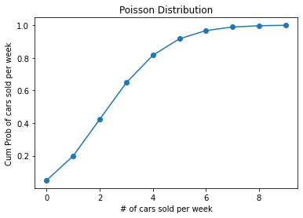

```python
# Plot poisson distribution function for cumulative probability of cars sold per-week vs number of cars sold per week
poisson = stats.poisson.cdf(n,rate)
plt.plot(n,poisson, 'o-')
plt.title('Poisson Distribution')
plt.xlabel('# of cars sold per week')
plt.ylabel('Cum Prob of cars sold per week')
plt.show()
```

4 Accuracy in understanding orders for a speech based bot at a restaurant is important for the Company X which has designed, marketed and launched the product for a contactless delivery due to the COVID-19 pandemic. Recognition accuracy that measures the percentage of orders that are taken correctly is 86.8%. Suppose that you place an order with the bot and two friends of yours independently place orders with the same bot. Answer the following questions. [3 Marks]

4.A. What is the probability that all three orders will be recognised correctly? [1 Mark]

4.B. What is the probability that none of the three orders will be recognised correctly? [1 Mark]

4.C. What is the probability that at least two of the three orders will be recognised correctly? [1 Mark]

```python
n=3
p=0.868
# P(x) = (n!/x!(n-x)!) *P^x * (1-p)^(n-x)
# Probability of x=3,let A be P(3)
# A= (3! / 3!(3-3)!) * 0.868^3 * (1-0.868)^(3-3)
A=1*0.654*1
print('4.A. probability that all three orders will be recognised correctly: %1.5f' %A)
```

```
4.A. probability that all three orders will be recognised correctly: 0.65400
```

```python
# Probability of x=0, Let B be P(0)
# B= (3! / 0!(3-0)!) * 0.868^0 * (1-0.868)^(3-0)
B=1*1*0.00229
print('4.B.  probability that none of the three orders will be recognised correctly: %1.5f' %B)
```

```
4.B.  probability that none of the three orders will be recognised correctly: 0.00229
```

```python
# Probability of x=2, Let C be P(2)
# C= (3! / 2!(3-2)!) * 0.868^2 * (1-0.868)^(3-2)
C=3*0.753*0.132
print('4.C.  probability that at least two of the three orders will be recognised correctly: %1.5f' %C)
```

[output not shown]

5 Explain 1 real life industry scenario (other than the ones mentioned above) where you can use the concepts learnt in this module of Applied Statistics to get data driven business solution. [3 Marks]

Accuracy in understanding orders that are returned on an online shopping mart is important for company X. It has taken a sample of 100 orders across locality  
Below Columns and data Shared: Product Id,Order ID, Customer ID, ProductCategory,customerlocality,ReturnFlag,ReturnReason,.. A) What is the probability of Order return rate? B) What is the Probability of customers who are not satisfied with the product, given that the people has returned the product C) List the Top selling product without any return D) List the least selling product with maximum return

## Part B - 30 Marks

```python
import pandas as pd
import numpy as np
```

```python
#df=pd.read_csv('/OneDrive - Reed Elsevier Group ICO Reed Elsevier Inc/Documents/AIML/Project/Applies Statistics/Basketball.csv')
df=pd.read_csv('DS+-+Part2+-+Basketball.csv')
df.head(61)
```

|  | Team | Tournament | Score | PlayedGames | WonGames | DrawnGames | LostGames | BasketScored | BasketGiven | TournamentChampion | Runner-up | TeamLaunch | HighestPositionHeld |
| --- | --- | --- | --- | --- | --- | --- | --- | --- | --- | --- | --- | --- | --- |
| 0 | Team 1 | 86 | 4385 | 2762 | 1647 | 552 | 563 | 5947 | 3140 | 33 | 23 | 1929 | 1 |
| 1 | Team 2 | 86 | 4262 | 2762 | 1581 | 573 | 608 | 5900 | 3114 | 25 | 25 | 1929 | 1 |
| 2 | Team 3 | 80 | 3442 | 2614 | 1241 | 598 | 775 | 4534 | 3309 | 10 | 8 | 1929 | 1 |
| 3 | Team 4 | 82 | 3386 | 2664 | 1187 | 616 | 861 | 4398 | 3469 | 6 | 6 | 1931to32 | 1 |
| 4 | Team 5 | 86 | 3368 | 2762 | 1209 | 633 | 920 | 4631 | 3700 | 8 | 7 | 1929 | 1 |
| ... | ... | ... | ... | ... | ... | ... | ... | ... | ... | ... | ... | ... | ... |
| 56 | Team 57 | 1 | 34 | 38 | 8 | 10 | 20 | 38 | 66 | - | - | 2009-10 | 20 |
| 57 | Team 58 | 1 | 22 | 30 | 7 | 8 | 15 | 37 | 57 | - | - | 1956-57 | 16 |
| 58 | Team 59 | 1 | 19 | 30 | 7 | 5 | 18 | 51 | 85 | - | - | 1951~52 | 16 |
| 59 | Team 60 | 1 | 14 | 30 | 5 | 4 | 21 | 34 | 65 | - | - | 1955-56 | 15 |
| 60 | Team 61 | 1 | - | - | - | - | - | - | - | - | - | 2017~18 | 9 |

61 rows × 13 columns

```python
df.info()
```

```
<class 'pandas.core.frame.DataFrame'>
RangeIndex: 61 entries, 0 to 60
Data columns (total 13 columns):
 #   Column               Non-Null Count  Dtype
---  ------               --------------  -----
 0   Team                 61 non-null     object
 1   Tournament           61 non-null     int64
 2   Score                61 non-null     object
 3   PlayedGames          61 non-null     object
 4   WonGames             61 non-null     object
 5   DrawnGames           61 non-null     object
 6   LostGames            61 non-null     object
 7   BasketScored         61 non-null     object
 8   BasketGiven          61 non-null     object
 9   TournamentChampion   61 non-null     object
 10  Runner-up            61 non-null     object
 11  TeamLaunch           61 non-null     object
 12  HighestPositionHeld  61 non-null     int64
dtypes: int64(2), object(11)
memory usage: 6.3+ KB
```

```python
#Observations on data
# 1. Column 'Score' Datatype was found as object even though it was storing integer values,
# Let's check for any non-numerical values n column score
scoreisdigit=pd.DataFrame(df.Score.str.isdigit())
scoreisdigit

df[scoreisdigit['Score']==False]
```

|  | Team | Tournament | Score | PlayedGames | WonGames | DrawnGames | LostGames | BasketScored | BasketGiven | TournamentChampion | Runner-up | TeamLaunch | HighestPositionHeld |
| --- | --- | --- | --- | --- | --- | --- | --- | --- | --- | --- | --- | --- | --- |
| 60 | Team 61 | 1 | - | - | - | - | - | - | - | - | - | 2017~18 | 9 |

```python
#Lets drop the row having non numeric data

df=df.drop(60)
df.tail(5)
```

|  | Team | Tournament | Score | PlayedGames | WonGames | DrawnGames | LostGames | BasketScored | BasketGiven | TournamentChampion | Runner-up | TeamLaunch | HighestPositionHeld |
| --- | --- | --- | --- | --- | --- | --- | --- | --- | --- | --- | --- | --- | --- |
| 55 | Team 56 | 1 | 35 | 38 | 8 | 11 | 19 | 36 | 55 | - | - | 2016_17 | 17 |
| 56 | Team 57 | 1 | 34 | 38 | 8 | 10 | 20 | 38 | 66 | - | - | 2009-10 | 20 |
| 57 | Team 58 | 1 | 22 | 30 | 7 | 8 | 15 | 37 | 57 | - | - | 1956-57 | 16 |
| 58 | Team 59 | 1 | 19 | 30 | 7 | 5 | 18 | 51 | 85 | - | - | 1951~52 | 16 |
| 59 | Team 60 | 1 | 14 | 30 | 5 | 4 | 21 | 34 | 65 | - | - | 1955-56 | 15 |

```python
df.info()
```

```
<class 'pandas.core.frame.DataFrame'>
Int64Index: 60 entries, 0 to 59
Data columns (total 13 columns):
 #   Column               Non-Null Count  Dtype
---  ------               --------------  -----
 0   Team                 60 non-null     object
 1   Tournament           60 non-null     int64
 2   Score                60 non-null     object
 3   PlayedGames          60 non-null     object
 4   WonGames             60 non-null     object
 5   DrawnGames           60 non-null     object
 6   LostGames            60 non-null     object
 7   BasketScored         60 non-null     object
 8   BasketGiven          60 non-null     object
 9   TournamentChampion   60 non-null     object
 10  Runner-up            60 non-null     object
 11  TeamLaunch           60 non-null     object
 12  HighestPositionHeld  60 non-null     int64
dtypes: int64(2), object(11)
memory usage: 6.6+ KB
```

```python
#Changing object to int datatype for columns storing numbers

df['Score']=df['Score'].astype(int)
df['PlayedGames']=df['PlayedGames'].astype(int)
df['WonGames']=df['WonGames'].astype(int)
df['DrawnGames']=df['DrawnGames'].astype(int)
df['LostGames']=df['LostGames'].astype(int)
df['BasketScored']=df['BasketScored'].astype(int)
df['BasketGiven']=df['BasketGiven'].astype(int)

# Removing special characters from the columns
df['TournamentChampion'] = df['TournamentChampion'].str.replace(r'\D+', '0')
df['Runner-up'] = df['Runner-up'].str.replace(r'\D+', '0')

df.info()
```

```
<class 'pandas.core.frame.DataFrame'>
Int64Index: 60 entries, 0 to 59
Data columns (total 13 columns):
 #   Column               Non-Null Count  Dtype
---  ------               --------------  -----
 0   Team                 60 non-null     object
 1   Tournament           60 non-null     int64
 2   Score                60 non-null     int32
 3   PlayedGames          60 non-null     int32
 4   WonGames             60 non-null     int32
 5   DrawnGames           60 non-null     int32
 6   LostGames            60 non-null     int32
 7   BasketScored         60 non-null     int32
 8   BasketGiven          60 non-null     int32
 9   TournamentChampion   60 non-null     object
 10  Runner-up            60 non-null     object
 11  TeamLaunch           60 non-null     object
 12  HighestPositionHeld  60 non-null     int64
dtypes: int32(7), int64(2), object(4)
memory usage: 4.9+ KB
```

```python
# Converting to Integer after removing the special character
df['TournamentChampion']=df['TournamentChampion'].astype(int)
df['Runner-up']=df['Runner-up'].astype(int)
df.info()
```

```
<class 'pandas.core.frame.DataFrame'>
Int64Index: 60 entries, 0 to 59
Data columns (total 13 columns):
 #   Column               Non-Null Count  Dtype
---  ------               --------------  -----
 0   Team                 60 non-null     object
 1   Tournament           60 non-null     int64
 2   Score                60 non-null     int32
 3   PlayedGames          60 non-null     int32
 4   WonGames             60 non-null     int32
 5   DrawnGames           60 non-null     int32
 6   LostGames            60 non-null     int32
 7   BasketScored         60 non-null     int32
 8   BasketGiven          60 non-null     int32
 9   TournamentChampion   60 non-null     int32
 10  Runner-up            60 non-null     int32
 11  TeamLaunch           60 non-null     object
 12  HighestPositionHeld  60 non-null     int64
dtypes: int32(9), int64(2), object(2)
memory usage: 4.5+ KB
```

```python
# For better analysis, derive new column'Teamlaunch_startyear' to have in 'YYYY' year format
df['TeamLaunch_startyear']=df['TeamLaunch'].str[:4]
df['TeamLaunch_startyear']=df['TeamLaunch_startyear'].astype(int)
df.info()
df.head()
```

```
<class 'pandas.core.frame.DataFrame'>
Int64Index: 60 entries, 0 to 59
Data columns (total 14 columns):
 #   Column                Non-Null Count  Dtype
---  ------                --------------  -----
 0   Team                  60 non-null     object
 1   Tournament            60 non-null     int64
 2   Score                 60 non-null     int32
 3   PlayedGames           60 non-null     int32
 4   WonGames              60 non-null     int32
 5   DrawnGames            60 non-null     int32
 6   LostGames             60 non-null     int32
 7   BasketScored          60 non-null     int32
 8   BasketGiven           60 non-null     int32
 9   TournamentChampion    60 non-null     int32
 10  Runner-up             60 non-null     int32
 11  TeamLaunch            60 non-null     object
 12  HighestPositionHeld   60 non-null     int64
 13  TeamLaunch_startyear  60 non-null     int32
dtypes: int32(10), int64(2), object(2)
memory usage: 4.7+ KB
```

|  | Team | Tournament | Score | PlayedGames | WonGames | DrawnGames | LostGames | BasketScored | BasketGiven | TournamentChampion | Runner-up | TeamLaunch | HighestPositionHeld | TeamLaunch_startyear |
| --- | --- | --- | --- | --- | --- | --- | --- | --- | --- | --- | --- | --- | --- | --- |
| 0 | Team 1 | 86 | 4385 | 2762 | 1647 | 552 | 563 | 5947 | 3140 | 33 | 23 | 1929 | 1 | 1929 |
| 1 | Team 2 | 86 | 4262 | 2762 | 1581 | 573 | 608 | 5900 | 3114 | 25 | 25 | 1929 | 1 | 1929 |
| 2 | Team 3 | 80 | 3442 | 2614 | 1241 | 598 | 775 | 4534 | 3309 | 10 | 8 | 1929 | 1 | 1929 |
| 3 | Team 4 | 82 | 3386 | 2664 | 1187 | 616 | 861 | 4398 | 3469 | 6 | 6 | 1931to32 | 1 | 1931 |
| 4 | Team 5 | 86 | 3368 | 2762 | 1209 | 633 | 920 | 4631 | 3700 | 8 | 7 | 1929 | 1 | 1929 |

```python
df.describe().T
```

|  | count | mean | std | min | 25% | 50% | 75% | max |
| --- | --- | --- | --- | --- | --- | --- | --- | --- |
| Tournament | 60.0 | 24.383333 | 26.884620 | 1.0 | 4.00 | 12.0 | 39.00 | 86.0 |
| Score | 60.0 | 916.450000 | 1138.342899 | 14.0 | 104.25 | 395.5 | 1360.50 | 4385.0 |
| PlayedGames | 60.0 | 810.100000 | 877.465393 | 30.0 | 115.50 | 424.5 | 1345.50 | 2762.0 |
| WonGames | 60.0 | 309.033333 | 408.481395 | 5.0 | 34.75 | 124.0 | 432.75 | 1647.0 |
| DrawnGames | 60.0 | 192.083333 | 201.985508 | 4.0 | 26.25 | 98.5 | 331.50 | 633.0 |
| LostGames | 60.0 | 308.816667 | 294.508639 | 15.0 | 62.75 | 197.5 | 563.50 | 1070.0 |
| BasketScored | 60.0 | 1159.350000 | 1512.063948 | 34.0 | 154.50 | 444.0 | 1669.75 | 5947.0 |
| BasketGiven | 60.0 | 1159.233333 | 1163.946914 | 55.0 | 236.00 | 632.5 | 2001.25 | 3889.0 |
| TournamentChampion | 60.0 | 1.450000 | 5.515540 | 0.0 | 0.00 | 0.0 | 0.00 | 33.0 |
| Runner-up | 60.0 | 1.433333 | 4.574679 | 0.0 | 0.00 | 0.0 | 0.00 | 25.0 |
| HighestPositionHeld | 60.0 | 7.050000 | 5.315232 | 1.0 | 3.00 | 6.0 | 10.00 | 20.0 |
| TeamLaunch_startyear | 60.0 | 1957.950000 | 26.646732 | 1929.0 | 1934.75 | 1950.5 | 1977.25 | 2016.0 |

Observation:

1. Scaling is required
2. Most columns like Score,PlayedGames,WonGames,DrawnGames,LostGames,Basketscored,BasketGiven values are suddenly increased between 50% and 75%, so there could be some data anomolies.

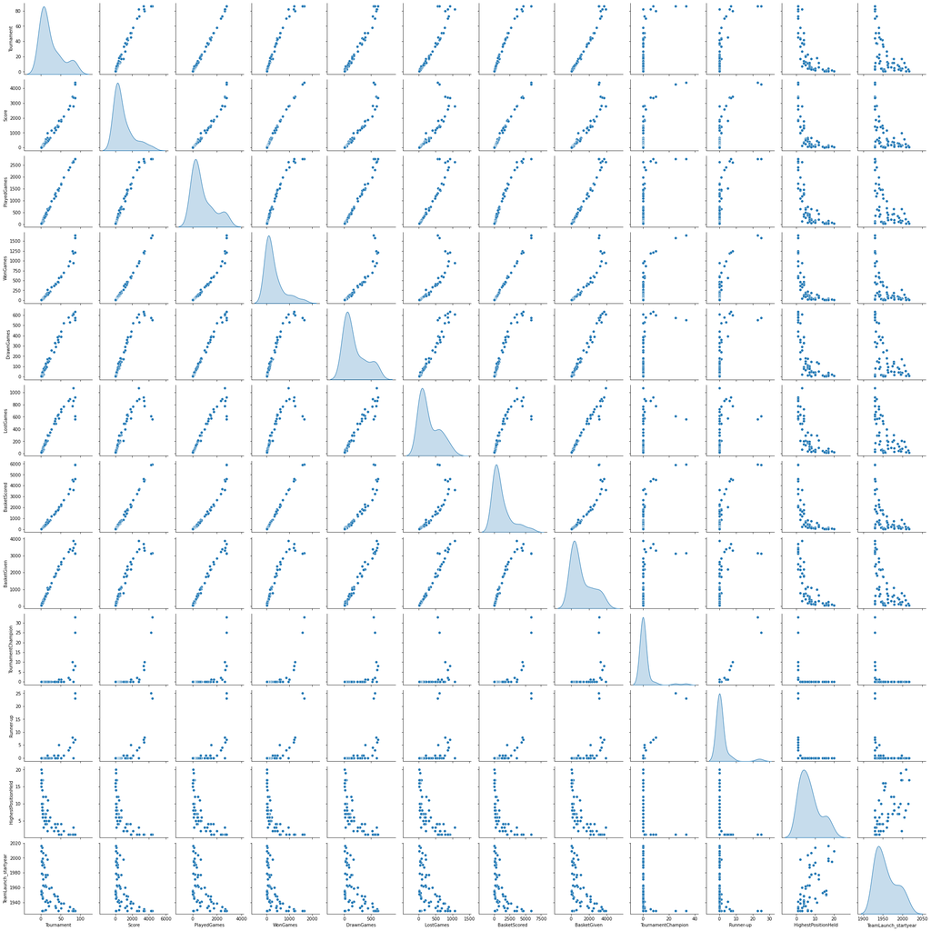

```python
#Visulaize the data using pairplot

import seaborn as sns
import matplotlib.pyplot as plt

sns.pairplot(df, diag_kind='kde')
```

```python
df
```

|  | Team | Tournament | Score | PlayedGames | WonGames | DrawnGames | LostGames | BasketScored | BasketGiven | TournamentChampion | Runner-up | TeamLaunch | HighestPositionHeld | TeamLaunch_startyear |
| --- | --- | --- | --- | --- | --- | --- | --- | --- | --- | --- | --- | --- | --- | --- |
| 0 | Team 1 | 86 | 4385 | 2762 | 1647 | 552 | 563 | 5947 | 3140 | 33 | 23 | 1929 | 1 | 1929 |
| 1 | Team 2 | 86 | 4262 | 2762 | 1581 | 573 | 608 | 5900 | 3114 | 25 | 25 | 1929 | 1 | 1929 |
| 2 | Team 3 | 80 | 3442 | 2614 | 1241 | 598 | 775 | 4534 | 3309 | 10 | 8 | 1929 | 1 | 1929 |
| 3 | Team 4 | 82 | 3386 | 2664 | 1187 | 616 | 861 | 4398 | 3469 | 6 | 6 | 1931to32 | 1 | 1931 |
| 4 | Team 5 | 86 | 3368 | 2762 | 1209 | 633 | 920 | 4631 | 3700 | 8 | 7 | 1929 | 1 | 1929 |
| 5 | Team 6 | 73 | 2819 | 2408 | 990 | 531 | 887 | 3680 | 3373 | 1 | 4 | 1934-35 | 1 | 1934 |
| 6 | Team 7 | 82 | 2792 | 2626 | 948 | 608 | 1070 | 3609 | 3889 | 0 | 0 | 1929 | 3 | 1929 |
| 7 | Team 8 | 70 | 2573 | 2302 | 864 | 577 | 861 | 3228 | 3230 | 2 | 3 | 1929 | 1 | 1929 |
| 8 | Team 9 | 58 | 2109 | 1986 | 698 | 522 | 766 | 2683 | 2847 | 0 | 1 | 1939-40 | 2 | 1939 |
| 9 | Team 10 | 51 | 1884 | 1728 | 606 | 440 | 682 | 2159 | 2492 | 1 | 0 | 1932-33 | 1 | 1932 |
| 10 | Team 11 | 45 | 1814 | 1530 | 563 | 392 | 575 | 2052 | 2188 | 1 | 5 | 1941to42 | 1 | 1941 |
| 11 | Team 12 | 51 | 1789 | 1698 | 586 | 389 | 723 | 2278 | 2624 | 0 | 0 | 1939-40 | 4 | 1939 |
| 12 | Team 13 | 42 | 1471 | 1466 | 463 | 384 | 619 | 1767 | 2180 | 0 | 0 | 1948-49 | 4 | 1948 |
| 13 | Team 14 | 44 | 1416 | 1428 | 453 | 336 | 639 | 1843 | 2368 | 0 | 1 | 1929 | 2 | 1929 |
| 14 | Team 15 | 43 | 1389 | 1458 | 471 | 358 | 629 | 1753 | 2152 | 0 | 1 | 1944_45 | 2 | 1944 |
| 15 | Team 16 | 37 | 1351 | 1318 | 426 | 327 | 565 | 1500 | 1834 | 0 | 0 | 1935-36 | 4 | 1935 |
| 16 | Team 17 | 36 | 1314 | 1255 | 390 | 330 | 535 | 1421 | 1763 | 0 | 0 | 1949_50 | 4 | 1949 |
| 17 | Team 18 | 38 | 1174 | 1192 | 408 | 292 | 492 | 1642 | 1951 | 0 | 0 | 1933to34 | 3 | 1933 |
| 18 | Team 19 | 27 | 1148 | 988 | 333 | 256 | 399 | 1182 | 1371 | 0 | 0 | 1960-61 | 3 | 1960 |
| 19 | Team 20 | 33 | 1020 | 1096 | 367 | 242 | 487 | 1347 | 1746 | 0 | 1 | 1951-52 | 2 | 1951 |
| 20 | Team 21 | 17 | 970 | 646 | 266 | 172 | 208 | 892 | 789 | 0 | 1 | 1998-99 | 2 | 1998 |
| 21 | Team 22 | 23 | 667 | 742 | 218 | 175 | 349 | 819 | 1157 | 0 | 0 | 1941-42 | 6 | 1941 |
| 22 | Team 23 | 17 | 662 | 652 | 189 | 148 | 305 | 760 | 1088 | 0 | 0 | 1977-78 | 8 | 1977 |
| 23 | Team 24 | 21 | 606 | 678 | 203 | 180 | 295 | 750 | 1022 | 0 | 0 | 1959-60 | 5 | 1959 |
| 24 | Team 25 | 12 | 553 | 456 | 147 | 112 | 197 | 520 | 633 | 0 | 0 | 2004to05 | 6 | 2004 |
| 25 | Team 26 | 20 | 538 | 628 | 184 | 149 | 295 | 716 | 1050 | 0 | 0 | 1935-36 | 5 | 1935 |
| 26 | Team 27 | 13 | 510 | 494 | 155 | 128 | 211 | 619 | 744 | 0 | 0 | 1961-62 | 5 | 1961 |
| 27 | Team 28 | 18 | 445 | 586 | 145 | 143 | 298 | 607 | 992 | 0 | 0 | 1940-41 | 11 | 1940 |
| 28 | Team 29 | 12 | 421 | 380 | 125 | 81 | 174 | 458 | 623 | 0 | 0 | 1930-31 | 6 | 1930 |
| 29 | Team 30 | 11 | 416 | 402 | 113 | 95 | 194 | 430 | 632 | 0 | 0 | 1963-64 | 6 | 1963 |
| 30 | Team 31 | 12 | 375 | 423 | 123 | 102 | 198 | 422 | 581 | 0 | 0 | 1974-75 | 7 | 1974 |
| 31 | Team 32 | 14 | 353 | 426 | 129 | 95 | 202 | 492 | 720 | 0 | 0 | 1943-44 | 4 | 1943 |
| 32 | Team 33 | 12 | 343 | 448 | 104 | 127 | 217 | 393 | 662 | 0 | 0 | 1977-78 | 12 | 1977 |
| 33 | Team 34 | 9 | 293 | 346 | 96 | 92 | 158 | 291 | 489 | 0 | 0 | 1987-88 | 7 | 1987 |
| 34 | Team 35 | 11 | 285 | 334 | 103 | 79 | 152 | 419 | 588 | 0 | 0 | 1941-42 | 4 | 1941 |
| 35 | Team 36 | 7 | 277 | 270 | 76 | 76 | 118 | 320 | 410 | 0 | 0 | 1991_92 | 7 | 1991 |
| 36 | Team 37 | 6 | 242 | 228 | 62 | 56 | 110 | 244 | 366 | 0 | 0 | 2007-08 | 8 | 2007 |
| 37 | Team 38 | 9 | 230 | 282 | 82 | 63 | 137 | 285 | 430 | 0 | 0 | 1962-63 | 5 | 1962 |
| 38 | Team 39 | 4 | 190 | 160 | 52 | 45 | 63 | 199 | 241 | 0 | 0 | 1994-95 | 10 | 1994 |
| 39 | Team 40 | 5 | 188 | 186 | 50 | 46 | 90 | 202 | 296 | 0 | 0 | 1978-79 | 8 | 1978 |
| 40 | Team 41 | 6 | 168 | 204 | 59 | 50 | 95 | 216 | 310 | 0 | 0 | 1971-72 | 12 | 1971 |
| 41 | Team 42 | 6 | 150 | 180 | 53 | 44 | 83 | 165 | 221 | 0 | 0 | 1963-64 | 7 | 1963 |
| 42 | Team 43 | 4 | 148 | 152 | 37 | 37 | 78 | 155 | 253 | 0 | 0 | 1999to00 | 17 | 1999 |
| 43 | Team 44 | 3 | 132 | 114 | 35 | 27 | 52 | 139 | 167 | 0 | 0 | 2014-15 | 10 | 2014 |
| 44 | Team 45 | 7 | 107 | 130 | 43 | 21 | 66 | 227 | 308 | 0 | 0 | 1929 | 3 | 1929 |
| 45 | Team 46 | 3 | 96 | 114 | 26 | 44 | 44 | 101 | 139 | 0 | 0 | 1990-91 | 9 | 1990 |
| 46 | Team 47 | 4 | 91 | 116 | 34 | 16 | 66 | 181 | 295 | 0 | 0 | 1947-48 | 7 | 1947 |
| 47 | Team 48 | 2 | 83 | 80 | 20 | 23 | 37 | 62 | 117 | 0 | 0 | 1996-97 | 17 | 1996 |
| 48 | Team 49 | 2 | 81 | 80 | 19 | 24 | 37 | 70 | 115 | 0 | 0 | 1995-96 | 19 | 1995 |
| 49 | Team 50 | 4 | 76 | 108 | 30 | 16 | 62 | 145 | 252 | 0 | 0 | 1945-46 | 10 | 1945 |
| 50 | Team 51 | 3 | 71 | 90 | 29 | 13 | 48 | 121 | 183 | 0 | 0 | 1953-54 | 14 | 1953 |
| 51 | Team 52 | 4 | 56 | 72 | 21 | 14 | 37 | 153 | 184 | 0 | 0 | 1929 | 6 | 1929 |
| 52 | Team 53 | 2 | 52 | 68 | 17 | 18 | 33 | 71 | 116 | 0 | 0 | 1979-80 | 10 | 1979 |
| 53 | Team 54 | 3 | 42 | 54 | 18 | 6 | 30 | 97 | 131 | 0 | 0 | 1929 | 8 | 1929 |
| 54 | Team 55 | 2 | 40 | 68 | 13 | 14 | 41 | 70 | 182 | 0 | 0 | 1950-51 | 16 | 1950 |
| 55 | Team 56 | 1 | 35 | 38 | 8 | 11 | 19 | 36 | 55 | 0 | 0 | 2016_17 | 17 | 2016 |
| 56 | Team 57 | 1 | 34 | 38 | 8 | 10 | 20 | 38 | 66 | 0 | 0 | 2009-10 | 20 | 2009 |
| 57 | Team 58 | 1 | 22 | 30 | 7 | 8 | 15 | 37 | 57 | 0 | 0 | 1956-57 | 16 | 1956 |
| 58 | Team 59 | 1 | 19 | 30 | 7 | 5 | 18 | 51 | 85 | 0 | 0 | 1951~52 | 16 | 1951 |
| 59 | Team 60 | 1 | 14 | 30 | 5 | 4 | 21 | 34 | 65 | 0 | 0 | 1955-56 | 15 | 1955 |

```python
df.TeamLaunch_startyear.value_counts()
```

```
1929    10
1941     3
1963     2
1977     2
1935     2
1951     2
1939     2
2016     1
1947     1
1994     1
1978     1
1971     1
1956     1
1999     1
2014     1
```

[output cut: 30 more lines]